# Python für Geisteswissenschaftler/innen

(Teil 1)

Melanie Andresen

melanie.andresen@uni-hamburg.de

## The Essence of Programming

“What I mean is that if you really want to understand something, the best way is to try and explain it to someone else. That forces you to sort it out in your own mind. And the more slow and dim-witted your pupil, the more you have to break things down into more and more simple ideas.

And that’s really the essence of programming. By the time you’ve sorted out a complicated idea into little steps that even a stupid machine can deal with, you’ve certainly learned something about it yourself. The teacher usually learns more than the pupil. Isn’t that true?“

― Douglas Adams, Dirk Gently’s Holistic Detective Agency

## Natürliche Sprachen vs. Programmiersprachen

- keine Mehrdeutigkeiten
- …
- ein Autor!

## Guido van Rossum

[figure not shown]

(https://upload.wikimedia.org/wikipedia/commons/6/66/Guido_van_Rossum_OSCON_2006.jpg by Doc Searls, CC BY-SA 2.0)

„Vor über sechs Jahren, im Dezember 1989, suchte ich nach einem Programmierprojekt, das mich über die Weihnachtswoche beschäftigen würde. Mein Büro würde geschlossen bleiben, aber ich hatte auch zu Hause einen PC und sonst nicht viel zu tun. Ich entschied mich, einen Interpreter für die Skriptsprache zu schreiben, über die ich kürzlich nachdachte: Ein Nachfolger von ABC, der auch Unix- und C-Hacker ansprechen würde. Ich wählte Python als Arbeitstitel für das Projekt, weil ich in einer leicht respektlosen Stimmung (und ein großer Fan des Monty Python’s Flying Circus) war.“

https://de.wikipedia.org/wiki/Guido_van_Rossum

## Anwendungsszenarien

- Texte in Wörter und Sätze segmentieren
- Wörter und Sätze zählen und sortieren (alphabetisch, nach Länge oder Frequenz),
- bestimmte Textteile extrahieren (z. B. alle wörtliche Rede aus einem Text extrahieren, Webseiten um Header etc. bereinigen …)
- automatische Annotationen zu Lemmata, Wortarten und Syntax
- Informationen über Texte tabellarisch zusammenstellen
- …

### Unser Anwendungsszenario: Das Foodblog-Korpus

- Korpus aus 150 Posts aus 15 deutschsprachigen Foodblogs
- Download: https://zenodo.org/record/1410445

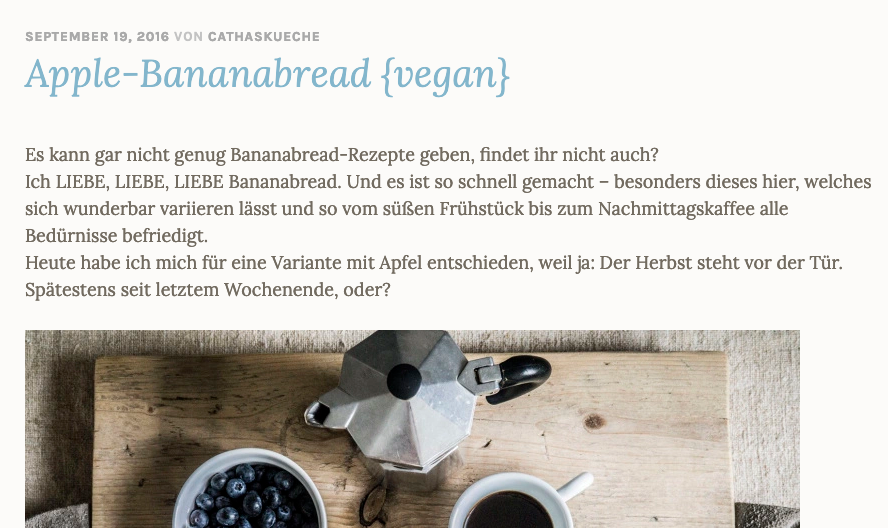

  https://cathaskueche.wordpress.com/2016/09/19/apple-bananabread-vegan/

### Mögliche Fragen an das Korpus

- Wie lang sind die Sätze der unterschiedlichen Autor*innen?
- Welches sind die häufigsten Adjektive im Korpus?
- Welche Zutaten kommen in den Rezepten am häufigsten vor?
- …

## In diesem Teil:

- Python im interaktiven Modus
- Variablen und Datentypen
- Pythonskripte speichern und ausführen
- Reguläre Ausdrücke

## Vorbereitungen

- Python 3 installiert?
- Texteditor vorhanden?
- Seminarordner angelegt?
- Foodblog-Korpus heruntergeladen?

## Navigation

Ein Terminalfenster öffnen:

- Mac: Terminal
- Windows: Eingabeaufforderung (cmd)

Orientieren:

- Wo sind wir eigentlich?  
  Mac: `pwd`
- Welche Dateien und Ordner gibt es hier?  
  Mac: `ls`  
  Windows: `dir`

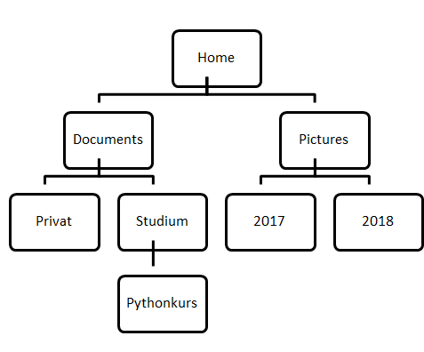

## Ort ändern:

- `cd` [Wunschort]

  z. B. `cd Documents/Studium`
- im Baum eine Ebene nach oben:

  `cd ..`
- zwei Ebenen nach oben:

  `cd ../..`
- aktueller Ort:

  `.`

ToDo: Navigiert in den Ordner mit dem Foodblog-Korpus!

## Weniger Tippen!

- mit der Tab-Taste autovervollständigen lassen
- mit dem Pfeil nach oben die letzten Befehle wieder aufrufen

## Inhalt von Textdateien ausgeben

Einfache Textdateien können aus dem Terminal heraus gelesen werden:

Mac: `cat bakingwithmarianne_01.txt`

Windows: `type bakingwithmarianne_01.txt`

Achtung: Das funktioniert nicht mit Binärdateien wie z. B. Word-Dateien.

## Python im interaktiven Modus starten

- Terminal/Eingabeaufforderung öffnen
- `python3` bzw. `py` (Windows) eingeben
- Pythonversion wird beim Start angezeigt (Prüfen: Ist es eine 3er-Version?)
- interaktiven Modus beenden: `quit()`

Aufgabe: Starte den interaktiven Modus und probiere Python wie einen Taschenrechner aus.

```python
5+6
```

```
11
```

## Variablen

A *variable* is something that holds a value that may change. In simplest terms, a variable is just a box that you can put stuff in.

https://en.wikibooks.org/wiki/Python_Programming/Variables_and_Strings

Wir geben dieser "Box" einen Namen und weisen ihr einen Inhalt zu:

```python
name = 'Karin'

alter = 32
```

## Variablennamen in Python

- Variablennamen beginnen mit einem Buchstaben `[a-zA-Z]` oder Unterstrich. Üblich: Kleinbuchstaben
- Variablennamen können Buchstaben `[a-zA-Z]`, Zahlen `[0-9]` und Unterstriche enthalten.
- In Variablennamen wird zwischen Groß- und Kleinschreibung unterschieden.

siehe z. B. https://www.w3schools.com/python/python_variables.asp

Variablennamen sollten leicht lesbar sein:

`namen_mitglieder = ...` ist besser als `namenmitglieder = ...`.

Variablennamen sollten interpretierbar sein:

`anzahl_mitglieder = 36` ist besser als `a = 36`.

→ Wichtig: Verständlichkeit für andere Leute und dich selbst, wenn du dir deinen Code nächste Woche wieder ansiehst.

## Datentypen: Zahlen

Python hat unterschiedliche Zahlenformate. Die wichtigsten sind:

- Integers sind ganze Zahlen, also Zahlen ohne Nachkommastellen.

```python
anzahl = 5
```

Gleitkommazahlen (floats) sind Dezimalzahlen, haben also Nachkommastellen.

```python
temperatur = 16.7
```

Wie im Englischen werden Dezimalstellen in Python mit einem Punkt abgetrennt.

## Grundrechenarten

```python
3 + 3
```

```
6
```

```python
7 - 4
```

```
3
```

```python
5 * 3
```

```
15
```

```python
20 / 4
```

```
5.0
```

Runden

```python
round(5.7)
```

```
6
```

Betrag

```python
abs(-4)
```

```
4
```

Höchsten Wert ermitteln

```python
max(4,98,17)
```

```
98
```

Niedrigsten Wert ermitteln

```python
min(4,98,17)
```

```
4
```

## Datentypen: Strings

Ein String ist eine Zeichenkette. Strings werden in Python durch einfache oder doppelte Anführungszeichen markiert:

```python
name = 'Karin'
```

In Python kann man Strings addieren und multiplizieren:

```python
'süß' + 'sauer'
```

```
'süßsauer'
```

```python
'bla' * 200
```

```
'blablablablablablablablablablablablablablablablablablablabla…'
```

## Datentypen

Welchen Datentyp hat meine Variable?

```python
alter = 32

type(alter)
```

```
int
```

Datentypen konvertieren

- in Integer: `int(alter)`
- in Float: `float(alter)`
- in String: `str(alter)`

Achtung, das Ergebnis muss wieder einer Variablen zugewiesen werden:

```python
alter = float(alter)
```

## Skripte schreiben und aufrufen

## Interaktiver Modus vs. Skript

Interaktiver Modus:

- Du befindest dich im Terminal/in der Eingabeaufforderung.
- Du bekommst eine direkte Rückgabe für deinen Input.

```python
>>> 6*7
```

```
42
```

- `>>>` zeigt an, dass der interaktive Modus aktiv ist und auf deinen Input wartet

Skript:

- Code wird im Editor geschrieben, in Dateien mit der Endung `.py` gespeichert und dann als Ganzes vom Python Interpreter ausgeführt.

`python hello_world.py`

- keine direkten Rückgaben: Die Eingabe `6*7` erzeugt keinen direkten Output.

→ `print(6*7)`

## Skripte ausführen

- Erstelle im Editor eine Datei mit dem Inhalt `print('Hello World!')` und speichere sie im Seminarordner unter dem Namen `hello_world.py`.
- Öffne ein Terminalfenster im Seminarordner (bzw. navigiere mithilfe von `cd` in den Seminarordner).
- Führe das Skript durch folgende Eingabe aus:

`python3 hello_world.py` bzw.

`py hello_world.py` (Windows)

## In- und Output in der Konsole

Die Funktion `input()`gibt Nutzer/innen des Skripts die Möglichkeit, etwas einzugeben. In Klammern steht dabei die zu beantwortende Frage. Die Antwort wird hier in der Variablen `color`gespeichert:

`color = input('Was ist deine Lieblingsfarbe?')`

Mit der Variablen kann dann weitergearbeitet werden, indem wir ihren Inhalt zum Beispiel wieder in der Konsole ausgeben lassen:

`print(color)`

## Methoden von Strings

```python
satz = 'Käsebrot ist ein gutes Brot.'
```

Groß- in Kleinbuchstaben konvertieren:

```python
satz_lower = satz.lower()
print(satz_lower)
```

```
käsebrot ist ein gutes brot.
```

String teilen:

```python
woerter = satz.split()
print(woerter)
```

```
['Käsebrot', 'ist', 'ein', 'gutes', 'Brot.']
```

String wieder zusammensetzen:

```python
woerter = ','.join(woerter)
print(woerter)
```

```
Käsebrot,ist,ein,gutes,Brot.
```

Zeichen(ketten) ersetzen:

```python
satz_2 = satz.replace('ein gutes', 'das beste')
print(satz_2)
```

```
Käsebrot ist das beste Brot.
```

## Slicing

```python
wort = 'Krimiautorin'
```

Nur einen bestimmten Teil des Wortes ausgeben:

```python
wort[3:7]
```

```
'miau'
```

Achtung:

1. Zählungen beginnen immer bei 0!
2. Das Ende ist immer exklusive gemeint, bezeichnet also das erste Zeichen, das nicht mehr dazugehören soll.

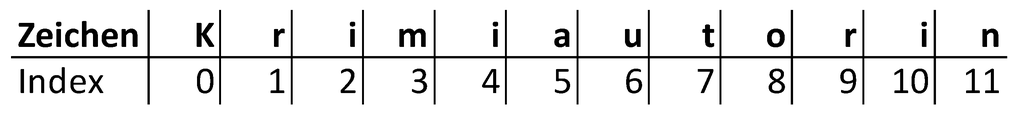

```python
wort = 'Krimiautorin'
```

Wenn wir den String nur auf einer Seite abschneiden wollen, können wir die Zahl auf der anderen Seite einfach weglassen:

```python
wort[5:]
```

```
'autorin'
```

```python
wort[:5]
```

```
'Krimi'
```

Wir können mit der Zählung auch von hinten anfangen:

```python
wort[5:-3]
```

```
'auto'
```

Das letzte Zeichen hat dann den Index -1.

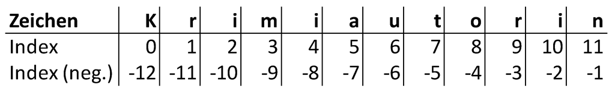

## Reguläre Ausdrücke

Suche nach Mustern statt nach konkreten Wortformen:

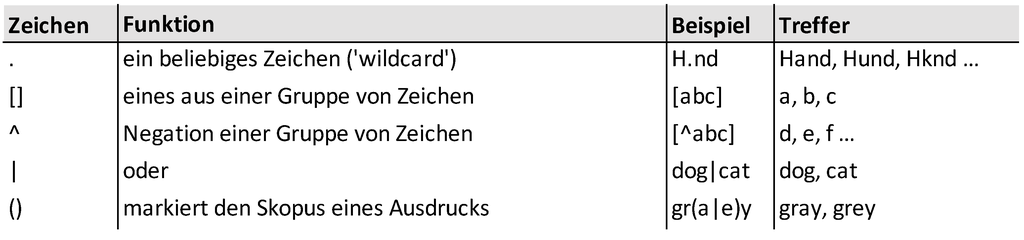

Suche nach Mustern statt nach konkreten Wortformen:

Quantifizierung:

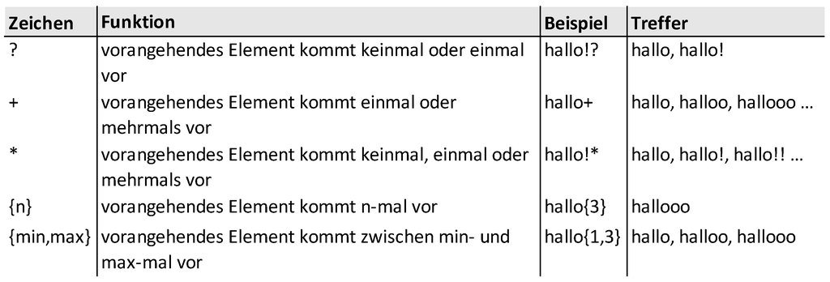

Suche nach Mustern statt nach konkreten Wortformen:

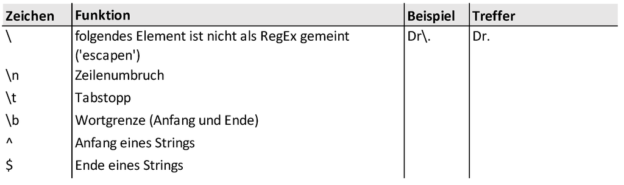

## Suchsyntax

Der optimale Suchausdruck soll

1. alle Belege finden, die uns interessieren (keine false negatives).
2. keine Belege finden, die uns nicht interessieren (keine false positives).

Achtung: Die Reduktion der einen Fehlergruppe führt häufig zur Vergrößerung der anderen Fehlergruppe.

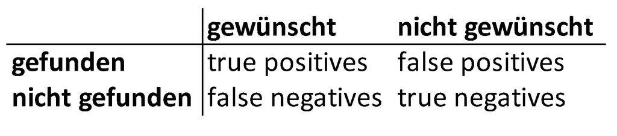

## Reguläre Ausdrücke in Python: Das `re`-Modul

Das `re`-Modul implementiert Funktionen mit regulären Ausdrücken, z. B.:

`re.findall(<pattern>, <string>)`

Gibt alle Vorkommen des Muster im String als Liste zurück.

Beispiel:

```python
import re

satz = 'Nach dem Laufen esse ich gerne Nudelauflauf.'
re.findall('[lL]auf', satz)
```

```
['Lauf', 'lauf', 'lauf']
```

Ist ein bestimmtes Muster im vorliegenden String enthalten?

`re.search(<pattern>, <string>)`

(Ergebnis ist ein komplexes Match Object, das viele Informationen enthält (s.u.) und einen Test posistiv ausfallen lässt.)

Beispiel:

```python
satz = 'Nach dem Laufen esse ich gerne Nudelauflauf.'
re.search('[lL]auf', satz)
```

```
<_sre.SRE_Match object; span=(9, 13), match='Lauf'>
```

Spezifischer: Steht ein bestimmtes Muster am Anfang des vorliegenden Strings?

`re.match(<pattern>, <string>)`

Damit können wir z. B. prüfen, ob der String mit einem Großbuchstaben beginnt:

```python
satz = 'Nach dem Laufen esse ich gerne Nudelauflauf.'

re.match('[A-ZÖÄÜ]', satz)
```

```
<_sre.SRE_Match object; span=(0, 1), match='N'>
```

Beide Funktionen nutzen wir später, um Bedingungen zu formulieren.

Inhalte suchen und ersetzen:

`re.sub(<pattern>, <replacement>, <string>)`

Beispiel:

```python
re.sub('[aeiouäü]+', 'ö', satz)
```

```
'Nöch döm Löfön össö öch görnö Nödölöflöf.'
```

## Matching Groups

Mit Matching Groups können wir uns auf bestimmte Teile des Trefferausdrucks beziehen. Man definiert Gruppen, indem Teile des Ausdrucks in runde Klammern gesetzt werden.

Aufgabe: Wir wollen aus den E-Mail-Adressen der Universität Hamburg automatisch die Nachnamen der Personen extrahieren. Schreibe zunächst einen Ausdruck, der Adressen der Universität Hamburg als solche erkennt.

Beispiel: `melanie.andresen@uni-hamburg.de`

`re.search()` gibt ein komplexes Match Object zurück. Das ermöglicht uns, gezielt auf bestimmte Teil zurückzugreifen, unter anderem die Matching Groups, die mit `.group()` ausgewählt werden können. Die Gruppe 0 (`.group(0)`) ist immer der ganze String:

```python
email = 'melanie.andresen@uni-hamburg.de'

treffer = re.search('[a-z]+\.[a-z]+@uni-hamburg\.de', email)
erste_gruppe = treffer.group(0)

print(erste_gruppe)
```

```
melanie.andresen@uni-hamburg.de
```

Alle weiteren Gruppen können wir durch runde Klammern definieren. Wir setzen deshalb Klammern um den Teil, der dem Nachnamen entspricht. Alle Teile des regulären Ausdrucks, die in runden Klammern stehen, werden dann von links nach rechts durchnummeriert. Die Gruppe, die dem Nachnamen entspricht, ist hier die Gruppe 1:

```python
treffer = re.search('[a-z]+\.([a-z]+)@uni\-hamburg\.de', email)
nachname = treffer.group(1)
print(nachname)
```

```
andresen
```

Gruppen können im gleichen regulären Ausdruck mit `\` plus ihrer Nummer wiederaufgenommen werden, um nach Wiederholungen zu suchen:

Suchausdruck: `([a-z])\1`

mögliche Treffer: aa, bb, cc, dd, ee, ...

## Training!

Spielen und sagen, man macht Hausaufgaben: http://codecombat.com

RegEx-Tutorial mit Übungen: https://regexone.com

Empfehlenswerter YouTube-Kanal zu Python: https://www.youtube.com/user/schafer5

## Code Combat

[figure not shown]

## Im nächsten Teil:

- Listen
- Boolsche Ausdrücke
- Bedingungen
- Schleifen
- Dateien einlesen und schreiben